# Mittlere motorische Testleistungen

Assoziationen mit Sportverein, Sport-AG, Normalgewicht und Geschlecht

Landesebene

Verein

Sport-AG

Konstitution

Geschlecht

Deskriptive Auswertung mittlerer motorischer Testleistungen in Klasse 3 nach Vereinsmitgliedschaft, Teilnahme an einer Sport-AG, Gewichtskategorie und Geschlecht.

Autor:innen

Zugehörigkeit

Toni Wöhrl

Universität Erfurt

Florian Bähr

Universität Erfurt

Veröffentlichungsdatum

26. Juni 2024

Geändert

17. September 2026

Zusammenfassung

Abbildungen zur genannten Überschrift, Punkte arithmetische Mittelwerte, Fehlerbalken 95% Konfidenzniveau

## 6-Minuten-Lauf

Die Auswertung der 6-Minuten-Lauf-Testwerte zeigt, dass Kinder durchschnittlich 961 [960; 963] m (Mittelwert und 95 %-Konfidenzintervall) zurücklegen. Jungen erreichen dabei etwa 994 [991; 996] m, Mädchen etwa 929 [928; 931] m; der mittlere Geschlechterunterschied (Jungen - Mädchen) beträgt damit ungefähr 64 m.

Im Mittel erreichen die besten Werte die Kinder mit der Merkmalskombination Vereinsmitgliedschaft, Teilnahme an einer Sport‑AG und Normalgewicht: Hier kommen Jungen auf durchschnittlich 1049 [1045; 1054] m, Mädchen auf 967 [962; 971] m. Verglichen mit den Kindern ohne Verein, ohne Sport-AG und ohne Normalgewicht entspricht die Spannweite der Leistungen bei den Jungen etwa 2.5-fachen Geschlechterunterschieden, bei den Mädchen liegt sie mit rund 1.5-fachen Geschlechterunterschieden etwas darunter.

Damit fallen die Leistungsunterschiede zwischen günstigster und ungünstigster Merkmalskombinationen deutlich stärker aus als der durchschnittliche Unterschied zwischen Jungen und Mädchen.

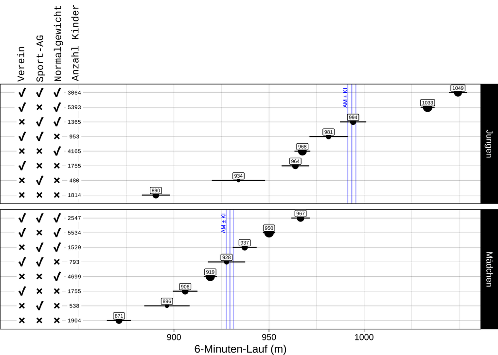

| Geschlecht | Anzahl | geschlechtsspezifischer Mittelwert in m [95%-KI] | Mittelwert aller Kinder in m [95%-KI] | Mittelwertunterschied Jungen-Mädchen in m | Spannweite gruppenspezifischer Mittelwerte in m | Spannweite gruppenspezifischer Mittelwerte in Einheiten des Geschlechterunterschieds |
| --- | --- | --- | --- | --- | --- | --- |
| Jungen | 18989 | 994 [991; 996] | 961 [960; 963] | 64 | 159 | 2.48 |
| Mädchen | 19299 | 929 [928; 931] | 961 [960; 963] | 64 | 96 | 1.49 |

## Sternlauf

Die Auswertung der Sternlauf-Ergebnisse zeigt, dass Kinder im Mittel rund 26.7 [26.7; 26.8] s für den Koordinationstest benötigen. Jungen erreichen dabei im Durchschnitt etwa 26.2 [26.2; 26.3] s, Mädchen etwa 27.2 [27.2; 27.3] s; der mittlere Geschlechterunterschied (Jungen - Mädchen) beträgt damit ungefähr -1 s.

Im Mittel erreichen die besten Werte (kürzeste Zeiten) die Kinder mit der Merkmalskombination Vereinsmitgliedschaft, Teilnahme an einer Sport‑AG und Normalgewicht: Hier kommen Jungen auf durchschnittlich 25.0 [24.9; 25.2] s, Mädchen auf 26.2 [26.0; 26.3] s. Verglichen mit den Kindern ohne Verein, ohne Sport-AG und ohne Normalgewicht entspricht die Spannweite der Leistungen bei den Jungen etwa 3.2-fachen Geschlechterunterschieden, bei den Mädchen liegt sie mit rund 2.4-fachen Geschlechterunterschieden etwas darunter.

Damit fallen die Leistungsunterschiede zwischen günstigster und ungünstigster Merkmalskombinationen deutlich stärker aus als der durchschnittliche Unterschied zwischen Jungen und Mädchen.

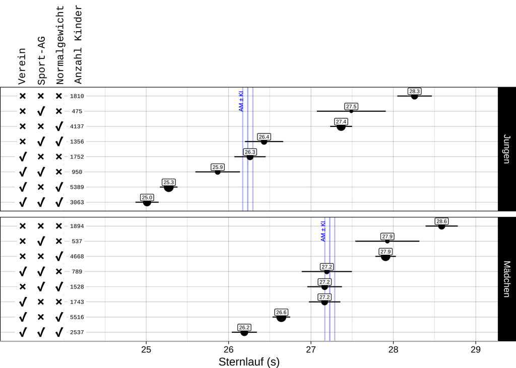

| Geschlecht | Anzahl | geschlechtsspezifischer Mittelwert in s [95%-KI] | Mittelwert aller Kinder in s [95%-KI] | Mittelwertunterschied Jungen-Mädchen in s | Spannweite gruppenspezifischer Mittelwerte in s | Spannweite gruppenspezifischer Mittelwerte in Einheiten des Geschlechterunterschieds |
| --- | --- | --- | --- | --- | --- | --- |
| Jungen | 18932 | 26.2 [26.2; 26.3] | 26.7 [26.7; 26.8] | -1.0 | 3.25 | -3.26 |
| Mädchen | 19212 | 27.2 [27.2; 27.3] | 26.7 [26.7; 26.8] | -1.0 | 2.40 | -2.41 |

## 20-Meter-Sprint

Die Auswertung der 20-Meter-Sprint-Ergebnisse zeigt, dass Kinder im Mittel rund 4.44 [4.43; 4.44] s für den Schnelligkeitstest benötigen. Jungen erreichen dabei im Durchschnitt etwa 4.37 [4.37; 4.38] s, Mädchen etwa 4.50 [4.49; 4.51] s; der mittlere Geschlechterunterschied (Jungen - Mädchen) beträgt damit ungefähr -0.13 s.

Damit fallen die Leistungsunterschiede zwischen günstigster und ungünstigster Merkmalskombinationen deutlich stärker aus als der durchschnittliche Unterschied zwischen Jungen und Mädchen.

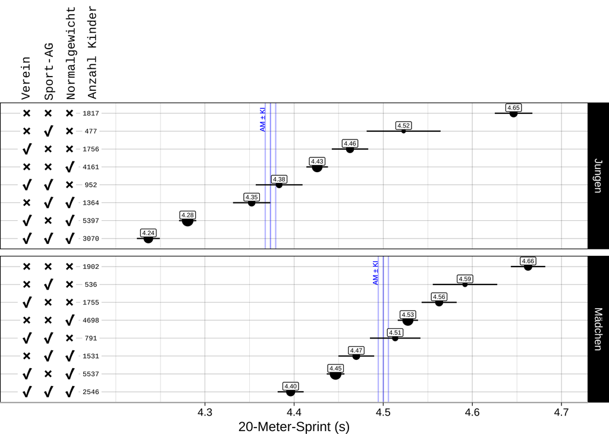

| Geschlecht | Anzahl | geschlechtsspezifischer Mittelwert in s [95%-KI] | Mittelwert aller Kinder in s [95%-KI] | Mittelwertunterschied Jungen-Mädchen in s | Spannweite gruppenspezifischer Mittelwerte in s | Spannweite gruppenspezifischer Mittelwerte in Einheiten des Geschlechterunterschieds |
| --- | --- | --- | --- | --- | --- | --- |
| Jungen | 18994 | 4.37 [4.37; 4.38] | 4.44 [4.43; 4.44] | -0.13 | 0.41 | -3.24 |
| Mädchen | 19296 | 4.50 [4.49; 4.51] | 4.44 [4.43; 4.44] | -0.13 | 0.27 | -2.10 |

## Medizinballstoßen

Die Auswertung des Medizinballstoßens zeigt, dass Kinder im Mittel rund 3.89 [3.88; 3.89] m weit stoßen. Jungen erreichen dabei im Durchschnitt etwa 4.13 [4.12; 4.14] m, Mädchen etwa 3.65 [3.64; 3.66] m; der mittlere Geschlechterunterschied (Jungen - Mädchen) beträgt damit ungefähr 0.48 m.

Die Merkmalskombinationen sind beim Wurftest mit unsicheren Leistungsunterschieden verbunden (stärkere Überlappungen der Konfidenzintervalle) als bei den Lauf-Tests und liegen eher in der Größenordnung des Geschlechterunterschieds oder darunter. Insbesondere scheint hierbei der Zusammenhang zum Normalgewicht eine vergleichsweise geringere Rolle zu spielen.

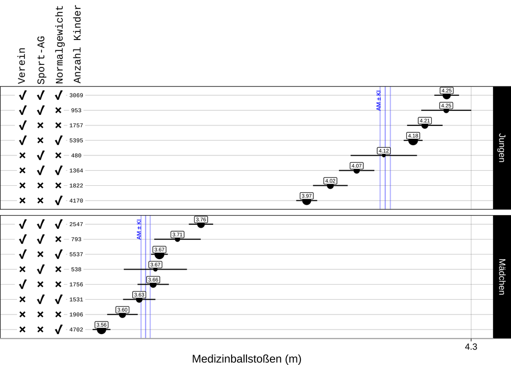

| Geschlecht | Anzahl | geschlechtsspezifischer Mittelwert in m [95%-KI] | Mittelwert aller Kinder in m [95%-KI] | Mittelwertunterschied Jungen-Mädchen in m | Spannweite gruppenspezifischer Mittelwerte in m | Spannweite gruppenspezifischer Mittelwerte in Einheiten des Geschlechterunterschieds |
| --- | --- | --- | --- | --- | --- | --- |
| Jungen | 19010 | 4.13 [4.12; 4.14] | 3.89 [3.88; 3.89] | 0.48 | 0.28 | 0.58 |
| Mädchen | 19310 | 3.65 [3.64; 3.66] | 3.89 [3.88; 3.89] | 0.48 | 0.20 | 0.42 |

## Standweitsprung

Damit fallen die Leistungsunterschiede zwischen günstigster und ungünstigster Merkmalskombinationen deutlich stärker aus als der durchschnittliche Unterschied zwischen Jungen und Mädchen.

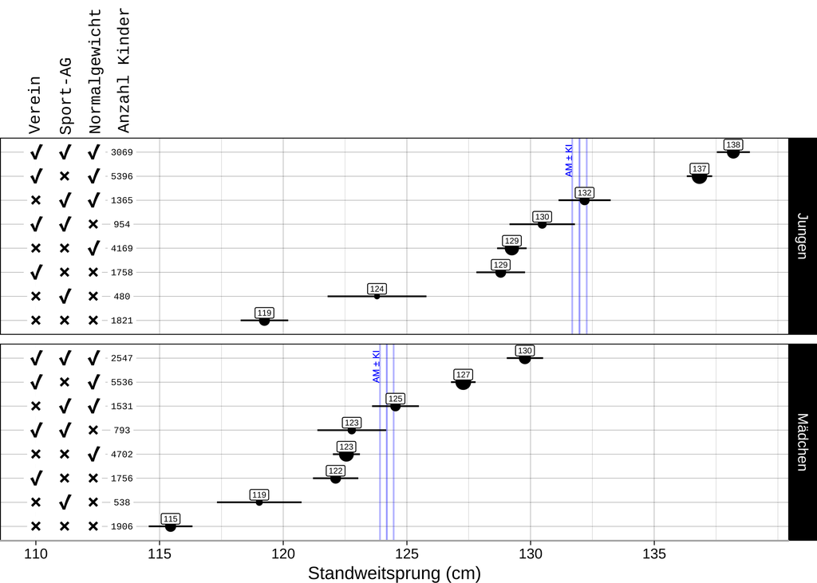

| Geschlecht | Anzahl | geschlechtsspezifischer Mittelwert in cm [95%-KI] | Mittelwert aller Kinder in cm [95%-KI] | Mittelwertunterschied Jungen-Mädchen in cm | Spannweite gruppenspezifischer Mittelwerte in cm | Spannweite gruppenspezifischer Mittelwerte in Einheiten des Geschlechterunterschieds |
| --- | --- | --- | --- | --- | --- | --- |
| Jungen | 19012 | 132.0 [131.7; 132.3] | 128.05 [127.8; 128.3] | 7.8 | 19 | 2.43 |
| Mädchen | 19309 | 124.2 [123.9; 124.5] | 128.05 [127.8; 128.3] | 7.8 | 14 | 1.84 |

## Datengrundlage

- BeKiGeKi Schuljahre von 2017/2018 bis 2023/2024
- Klassifikation Normalgewicht (Perzentil P10-P90) auf Grundlage der Veröffentlichung: Kromeyer-Hauschild, K., Wabitsch, M., Kunze, D., Geller, F., Geiß, H. C., Hesse, V., von Hippel, A., Jaeger, U., Johnsen, D., Korte, W., Menner, K., Müller, G., Müller, J. M., Niemann-Pilatus, A., Remer, T., Schaefer, F., Wittchen, H.-U., Zabransky, S., Zellner, K., … Hebebrand, J. (2001). Perzentile für den Body-mass-Index für das Kindes- und Jugendalter unter Heranziehung verschiedener deutscher Stichproben. Monatsschrift Kinderheilkunde, 149(8), 807–818.
- Die Auswertungen basieren ausschließlich auf vollständigen Datensätzen, d.h. es wurden nur Kinder berücksichtigt, für die alle sechs Testwerte vorlagen. Zusätzlich gingen nur Fälle in die Analyse ein, in denen freiwillige Angaben zu Körpermasse und Körpergröße sowie zur Vereinsmitgliedschaft und zur Teilnahme an einer Sport-AG vorhanden waren. Daten von Kindern aus Förder- und Ergänzungsschulen wurden von den Auswertungen ausgeschlossen.

## TODO

- Einbeinstand
- Umstellung evtl. auf Median und Quantile
- Zusammenfassung über alle Tests

## Aktualisierungen

- 2026-05-26: Datengrundlage, Aufnahme Abbildungen ins Abbildungsverzeichnis
- 2026-05-05: Medizinballstoßen, Tabellen mit Bezug auf Geschlechtsunterschiede, Prosa
- 2024-06-26: Veröffentlichung